# Bioestadística Fundamental

Departamento de Estadística, Sede Bogotá

## Contenido

### Parte I: Introducción y diseño 2²

- Motivación de los diseños factoriales 2^k.
- El diseño 2²: tabla de signos y contrastes.
- Cálculo de efectos y sumas de cuadrados.
- Tabla ANOVA, decisión e interpretación.

### Parte II: El diseño 2³

- Extensión a tres factores: 8 combinaciones.
- Los siete efectos estimables.
- Tabla ANOVA e interpretación de interacciones.

### Parte III: Diseño 2^k general

- Generalización a k factores y algoritmo de Yates.
- Réplica única: gráfico normal de efectos.
- Ejemplo: screening 2⁴ en cacao.
- Puntos centrales y prueba de curvatura.

### Parte IV: Taller en clase

- Ejercicios con diseños 2² y 2³.
- Aplicaciones agrícolas colombianas.

Diseño Factorial 2^k

¿Cómo evaluar simultáneamente el efecto de varios factores agronómicos, y sus interacciones, con el menor número de experimentos posible?

## Motivación: factores cuantitativos y cualitativos a dos niveles

En investigación agrícola es común que el rendimiento de un cultivo dependa de **varios factores simultáneamente**: riego, fertilización, densidad de siembra, control fitosanitario, variedad. Evaluar cada factor por separado, uno a la vez, ignora las posibles **interacciones** entre ellos.

El **diseño factorial 2^k** evalúa $k$ factores, cada uno a **dos niveles** (alto/bajo, presente/ausente), permitiendo estimar todos los efectos principales y todas las interacciones con un número reducido y eficiente de corridas experimentales.

## ¿Por qué dos niveles?

Eficiencia (screening)

Con solo $2^k$ combinaciones se exploran $k$ factores. Para $k=4$, solo 16 corridas en lugar de explorar exhaustivamente cada combinación con muchos niveles.

Base para optimización

Los diseños 2^k son la base de las metodologías de superficie de respuesta, usadas para optimizar dosis óptimas de fertilizante, agua o densidad de siembra.

Los niveles “alto” y “bajo” se codifican convencionalmente como $+1$ y $-1$ (notación $+$ y $-$).

## Ejemplo introductorio: arroz en el Tolima

Un agrónomo del Tolima desea evaluar el efecto de dos factores sobre el **rendimiento de arroz** (ton/ha): el **nivel de riego** (Factor A: bajo/alto) y la **dosis de fertilizante nitrogenado** (Factor B: baja/alta). Se ejecuta un diseño $2^2$ con $n=4$ réplicas por combinación ($N=16$ parcelas en total).

Las cuatro combinaciones posibles se notan: $(1)$ = ambos en nivel bajo, $a$ = A alto y B bajo, $b$ = A bajo y B alto, $ab$ = ambos en nivel alto.

## Tabla de signos del diseño 2²

La tabla de signos codifica el nivel bajo como $-$ y el nivel alto como $+$ para cada factor y para la interacción $AB$ (producto de signos):

| Tratamiento | A (Riego) | B (Fertilizante) | AB |
| --- | --- | --- | --- |
| $(1)$ | $-$ | $-$ | $+$ |
| $a$ | $+$ | $-$ | $-$ |
| $b$ | $-$ | $+$ | $-$ |
| $ab$ | $+$ | $+$ | $+$ |

El signo de la interacción $AB$ se obtiene multiplicando los signos de A y de B en cada fila.

## Datos del experimento: rendimiento de arroz (ton/ha)

| Trat. | A | B | Rep 1 | Rep 2 | Rep 3 | Rep 4 | Total |
| --- | --- | --- | --- | --- | --- | --- | --- |
| $(1)$ | $-$ | $-$ | 5.72 | 5.94 | 5.63 | 5.85 | **23.14** |
| $a$ | $+$ | $-$ | 6.68 | 6.89 | 6.75 | 6.57 | **26.89** |
| $b$ | $-$ | $+$ | 6.53 | 6.24 | 6.43 | 6.10 | **25.30** |
| $ab$ | $+$ | $+$ | 8.26 | 7.53 | 7.84 | 7.85 | **31.48** |

$N=16$ parcelas, $n=4$ réplicas por combinación. Media general $\bar y_{..}=6.676$ ton/ha.

## Cálculo de efectos mediante contrastes

El **contraste** de un efecto se obtiene multiplicando cada total de tratamiento por su signo en la tabla de signos, y sumando:

Contraste y efecto

$$\text{Contraste}_X=\sum (\text{signo de } X)\times(\text{Total del tratamiento})$$
$$\text{Efecto}_X=\frac{\text{Contraste}_X}{2^{k-1}n}$$

**Contraste A:**
$$\text{Contraste}_A=-23.14+26.89-25.30+31.48=9.93$$
$$\text{Efecto}_A=\frac{9.93}{2^{1}(4)}=\frac{9.93}{8}=1.241 \text{ ton/ha}$$

## Cálculo de efectos B y AB

**Contraste B:**
$$\text{Contraste}_B=-23.14-26.89+25.30+31.48=6.75$$
$$\text{Efecto}_B=\frac{6.75}{8}=0.844 \text{ ton/ha}$$

**Contraste AB:**
$$\text{Contraste}_{AB}=23.14-26.89-25.30+31.48=2.43$$
$$\text{Efecto}_{AB}=\frac{2.43}{8}=0.304 \text{ ton/ha}$$

El riego (A) tiene el mayor efecto sobre el rendimiento; la interacción AB es pequeña pero, como se verá, estadísticamente significativa.

## Suma de cuadrados de cada efecto

Para un diseño $2^k$ con $n$ réplicas, la suma de cuadrados de cualquier efecto $X$ se calcula directamente a partir de su contraste:

Suma de cuadrados de un efecto

$$SC_X=\frac{(\text{Contraste}_X)^2}{2^k n}$$

$$SC_A=\frac{(9.93)^2}{4(4)}=\frac{98.60}{16}=6.163 \qquad SC_B=\frac{(6.75)^2}{16}=2.848$$
$$SC_{AB}=\frac{(2.43)^2}{16}=0.369$$

## Tabla ANOVA del diseño 2²: ejemplo del arroz

| Fuente | SC | gl | CM | F | valor-p |
| --- | --- | --- | --- | --- | --- |
| A: Riego | 6.163 | 1 | 6.163 | 150.84 | $3.7\times10^{-8}$ |
| B: Fertilizante | 2.848 | 1 | 2.848 | 69.70 | $2.4\times10^{-6}$ |
| AB | 0.369 | 1 | 0.369 | 9.03 | 0.011 |
| Error | 0.490 | 12 | 0.041 |  |  |
| Total | 9.870 | 15 |  |  |  |

Los tres efectos (A, B y AB) son significativos con $\alpha=0.05$, pues sus valores-p son todos menores a 0.05.

## Criterio de decisión y conclusión: arroz

Criterio de decisión

Con $F_{0.05,1,12}=4.75$:
$$F_A=150.84,\;F_B=69.70,\;F_{AB}=9.03$$
Los tres superan el valor crítico: se rechaza $H_0$ en cada caso.

Conclusión

El riego y la dosis de fertilizante afectan significativamente el rendimiento de arroz, y existe una interacción significativa: el efecto del fertilizante depende del nivel de riego.

## Gráfico de interacción: arroz en el Tolima

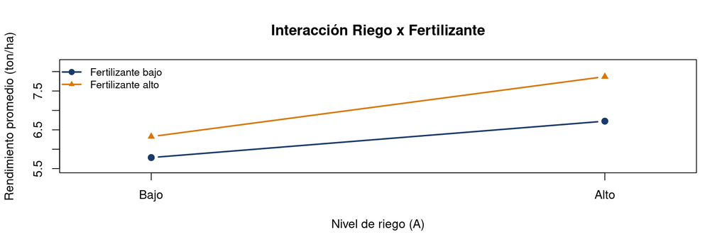

Las líneas no son paralelas: el incremento de rendimiento al pasar de fertilización baja a alta es mayor cuando el riego está en nivel alto. Esto confirma la interacción AB detectada en el ANOVA.

## Gráfico de cubo del diseño 2²

[figure not shown]

El vértice $ab$ (riego alto, fertilizante alto) presenta el mayor rendimiento promedio: 7.87 ton/ha.

El diseño 2³: tres factores en el cultivo de café

¿Qué ocurre cuando se desea evaluar tres prácticas agronómicas simultáneamente, y sus posibles interacciones de segundo y tercer orden?

## Extensión a tres factores: café en el Huila

Un agrónomo del Huila evalúa el efecto de tres factores sobre el **rendimiento de café** (sacos/ha): **A** = nivel de riego, **B** = dosis de fertilizante, **C** = densidad de siembra. El diseño $2^3$ genera $8$ combinaciones, cada una con $n=3$ réplicas ($N=24$ parcelas).

Con tres factores existen $2^3-1=7$ efectos estimables: 3 efectos principales (A, B, C), 3 interacciones de dos factores (AB, AC, BC) y 1 interacción de tres factores (ABC).

## Tabla de signos del diseño 2³ (orden estándar)

| Trat. | A | B | C | AB | AC | BC | ABC |
| --- | --- | --- | --- | --- | --- | --- | --- |
| $(1)$ | $-$ | $-$ | $-$ | $+$ | $+$ | $+$ | $-$ |
| $a$ | $+$ | $-$ | $-$ | $-$ | $-$ | $+$ | $+$ |
| $b$ | $-$ | $+$ | $-$ | $-$ | $+$ | $-$ | $+$ |
| $ab$ | $+$ | $+$ | $-$ | $+$ | $-$ | $-$ | $-$ |
| $c$ | $-$ | $-$ | $+$ | $+$ | $-$ | $-$ | $+$ |
| $ac$ | $+$ | $-$ | $+$ | $-$ | $+$ | $-$ | $-$ |
| $bc$ | $-$ | $+$ | $+$ | $-$ | $-$ | $+$ | $-$ |
| $abc$ | $+$ | $+$ | $+$ | $+$ | $+$ | $+$ | $+$ |

Los signos de las interacciones se obtienen multiplicando los signos de los factores correspondientes en cada fila.

## Datos del experimento: rendimiento de café (sacos/ha)

| Trat. | A | B | C | Rep1 | Rep2 | Rep3 | Total |
| --- | --- | --- | --- | --- | --- | --- | --- |
| $(1)$ | $-$ | $-$ | $-$ | 36.87 | 37.56 | 37.66 | **112.09** |
| $a$ | $+$ | $-$ | $-$ | 44.15 | 44.85 | 43.57 | **132.57** |
| $b$ | $-$ | $+$ | $-$ | 38.22 | 37.07 | 39.31 | **114.60** |
| $ab$ | $+$ | $+$ | $-$ | 44.47 | 43.86 | 45.18 | **133.51** |
| $c$ | $-$ | $-$ | $+$ | 40.22 | 40.89 | 42.67 | **123.78** |
| $ac$ | $+$ | $-$ | $+$ | 51.74 | 53.97 | 51.44 | **157.15** |
| $bc$ | $-$ | $+$ | $+$ | 40.96 | 41.45 | 40.34 | **122.75** |
| $abc$ | $+$ | $+$ | $+$ | 50.88 | 50.90 | 50.75 | **152.53** |

## Cálculo de los siete efectos: café

Igual que en el 2², cada contraste se divide por $2^{k-1}n=2^2(3)=12$:

| Efecto | Contraste | Efecto estimado | $SC$ |
| --- | --- | --- | --- |
| A | 102.54 | 8.545 | 438.10 |
| B | -2.20 | -0.183 | 0.20 |
| C | 63.44 | 5.287 | 167.69 |
| AB | -5.16 | -0.430 | 1.11 |
| AC | 23.76 | 1.980 | 23.52 |
| BC | -9.10 | -0.758 | 3.45 |
| ABC | -2.02 | -0.168 | 0.17 |

$SC_X=(\text{Contraste}_X)^2/(2^k n)=(\text{Contraste}_X)^2/24$.

## Tabla ANOVA del diseño 2³: café

| Fuente | SC | gl | CM | F | valor-p |
| --- | --- | --- | --- | --- | --- |
| A: Riego | 438.10 | 1 | 438.10 | 572.97 | $5.9\times10^{-14}$ |
| B: Fertilizante | 0.20 | 1 | 0.20 | 0.26 | 0.610 |
| C: Densidad | 167.69 | 1 | 167.69 | 219.32 | $9.3\times10^{-11}$ |
| AB | 1.11 | 1 | 1.11 | 1.45 | 0.246 |
| AC | 23.52 | 1 | 23.52 | 30.76 | $4.4\times10^{-5}$ |
| BC | 3.45 | 1 | 3.45 | 4.51 | 0.050 |
| ABC | 0.17 | 1 | 0.17 | 0.22 | 0.643 |
| Error | 12.24 | 16 | 0.765 |  |  |
| Total | 646.48 | 23 |  |  |  |

## Interpretación: ¿cuáles efectos son significativos?

**Significativos ($\alpha=0.05$):**  
A (riego), C (densidad), AC (interacción riego x densidad).

**No significativos:**  
B (fertilizante), AB, BC (límite, $p=0.05$), ABC.

El factor B (fertilizante) por sí solo no afecta significativamente el rendimiento en el rango estudiado, pero sí existe una interacción AC fuerte: el efecto de la densidad de siembra depende del nivel de riego. Esto sugiere que la práctica óptima combina riego alto y alta densidad.

## Gráfico de cubo del diseño 2³: café

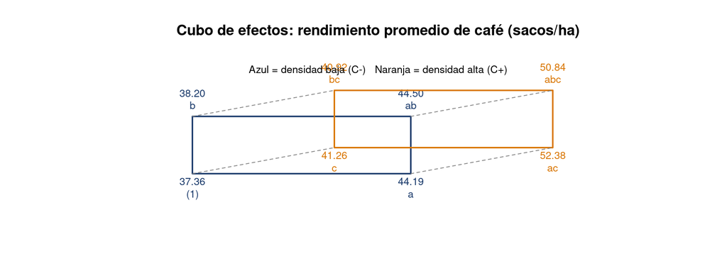

La combinación $ac$ (riego alto, densidad alta) presenta el mayor rendimiento promedio: 52.38 sacos/ha.

## Errores comunes en diseños 2² y 2³

Advertencia: errores frecuentes

- Interpretar un efecto principal grande sin revisar si existe una interacción significativa que lo modifique.
- Olvidar dividir el contraste por $2^{k-1}n$ (y no por $N$) al calcular el efecto.
- Confundir el signo de la interacción en la tabla de signos (se obtiene multiplicando los signos individuales, no sumándolos).
- Concluir significancia de un efecto solo por su magnitud, sin comparar su $F$ con el valor crítico o revisar el valor-p.

El diseño 2^k general y la réplica única

¿Cómo se generaliza el procedimiento a k factores, y qué hacer cuando ejecutar réplicas completas es demasiado costoso?

## Generalización a k factores

Un diseño $2^k$ evalúa $k$ factores a dos niveles cada uno, generando $2^k$ combinaciones de tratamiento. El número de efectos estimables es siempre $2^k-1$.

| $k$ | Combinaciones $2^k$ | Efectos estimables $2^k-1$ |
| --- | --- | --- |
| 2 | 4 | 3 (A, B, AB) |
| 3 | 8 | 7 |
| 4 | 16 | 15 |
| 5 | 32 | 31 |

El número de combinaciones crece exponencialmente: a partir de $k=5$ es frecuente usar diseños fraccionados o réplica única.

## Algoritmo de Yates

El **algoritmo de Yates** es un procedimiento sistemático para calcular todos los $2^k-1$ contrastes (y por tanto los efectos) sin tener que construir manualmente cada producto de signos.

Se ordenan los totales de tratamiento en **orden estándar** ($(1), a, b, ab, c, ac, \ldots$) y se aplican $k$ ciclos sucesivos de sumas y diferencias por pares consecutivos. Al final del ciclo $k$, la columna resultante contiene directamente los contrastes de todos los efectos, en el mismo orden estándar.

Cada efecto se obtiene dividiendo su contraste de Yates por $2^{k-1}n$, y cada suma de cuadrados dividiendo el contraste al cuadrado por $2^k n$, exactamente igual que en los casos 2² y 2³.

## Réplica única del diseño 2^k: motivación

Cuando $k$ es grande (4, 5 o más factores), ejecutar **varias réplicas completas** de las $2^k$ combinaciones puede ser extremadamente costoso: parcelas, insumos, tiempo de cosecha, mano de obra.

Con $k=4$ y $n=2$ réplicas se necesitan 32 parcelas; con $n=4$, 64 parcelas: con frecuencia inviable en investigación de campo.

La solución práctica: ejecutar una **réplica única** ($n=1$), es decir, una sola observación por combinación.

El problema: sin réplicas no hay grados de libertad para estimar directamente el error experimental.

## Estimación del error sin réplicas

La solución de Daniel (1959) se basa en un supuesto razonable en la mayoría de sistemas agrícolas:

Supuesto de esparsidad de efectos

Los efectos principales y las interacciones de bajo orden (2 factores) tienden a ser los más importantes. Las interacciones de **orden alto** (3 factores o más) suelen ser pequeñas y se comportan como **ruido aleatorio**.

Si la mayoría de los $2^k-1$ efectos son realmente cero (solo ruido), graficarlos en un papel de probabilidad normal debería mostrar la mayoría alineados sobre una recta, y solo los pocos efectos **activos** se desviarán de esa recta.

## Gráfico de probabilidad normal de los efectos

Para cada uno de los $2^k-1$ efectos estimados, se calcula su valor teórico esperado bajo normalidad (eje x) y se grafica contra el efecto estimado (eje y).

Interpretación del gráfico normal de efectos

Efectos sobre la recta $\Rightarrow$ ruido (no significativos).  
Efectos alejados de la recta $\Rightarrow$ activos (significativos).

Este método es puramente gráfico: no requiere un cuadrado medio del error calculado de antemano, justamente porque no hay réplicas para estimarlo directamente.

## Ejemplo: screening de prácticas agronómicas en cacao (Santander)

Un agrónomo en Santander evalúa $4$ prácticas sobre el **rendimiento de cacao seco** (kg/ha) mediante un diseño $2^4$ **sin réplica** (16 corridas): **A** = poda de mantenimiento, **B** = sombra regulada, **C** = fertilización orgánica, **D** = control biológico de moniliasis.

Con $k=4$ existen $2^4-1=15$ efectos estimables, pero solo 16 observaciones (una por combinación): sin réplicas, no hay grados de libertad para el error si se ajusta el modelo completo.

## Datos del diseño 2⁴ sin réplica: cacao

| Trat. | A | B | C | D | y (kg/ha) |
| --- | --- | --- | --- | --- | --- |
| $(1)$ | - | - | - | - | 1058.5 |
| $a$ | + | - | - | - | 1174.7 |
| $b$ | - | + | - | - | 1075.6 |
| $ab$ | + | + | - | - | 1183.0 |
| $c$ | - | - | + | - | 1127.9 |
| $ac$ | + | - | + | - | 1393.0 |
| $bc$ | - | + | + | - | 1132.4 |
| $abc$ | + | + | + | - | 1386.7 |
| $d$ | - | - | - | + | 1075.6 |
| $ad$ | + | - | - | + | 1192.4 |
| $bd$ | - | + | - | + | 1095.7 |
| $abd$ | + | + | - | + | 1205.0 |
| $cd$ | - | - | + | + | 1155.1 |
| $acd$ | + | - | + | + | 1404.3 |
| $bcd$ | - | + | + | + | 1151.7 |
| $abcd$ | + | + | + | + | 1399.6 |

## Los 15 efectos estimados: cacao

[output not shown]

Los efectos A, C y AC se destacan claramente en magnitud sobre los demás.

## Gráfico de probabilidad normal de efectos: cacao

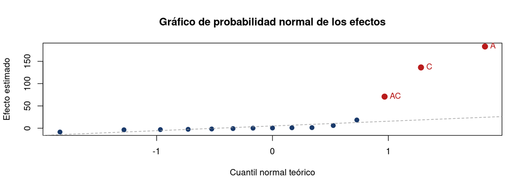

Los efectos A, C y AC se alejan claramente de la recta (resaltados en rojo): son los efectos activos. Los 12 efectos restantes se alinean sobre la recta y se interpretan como ruido aleatorio.

## Modelo reducido y ANOVA: cacao

Con base en el gráfico normal, se ajusta un **modelo reducido** que conserva únicamente los efectos activos (A, C, AC); los 12 efectos restantes se agrupan (“pooling”) para estimar el error experimental:

| Fuente | SC | gl | CM | F | valor-p |
| --- | --- | --- | --- | --- | --- |
| A: Poda | 134358.9 | 1 | 134358.9 | 832.9 | $1.9\times10^{-12}$ |
| C: Fert. orgánica | 74283.5 | 1 | 74283.5 | 460.5 | $6.1\times10^{-11}$ |
| AC | 20078.9 | 1 | 20078.9 | 124.5 | $1.1\times10^{-7}$ |
| Error (pooled) | 1936.5 | 12 | 161.4 |  |  |
| Total | 230657.8 | 15 |  |  |  |

El modelo reducido explica el $99.2\%$ de la variabilidad ($R^2=0.992$): la poda, la fertilización orgánica y su interacción son las prácticas clave para mejorar el rendimiento del cacao.

## Interpretación: screening en cacao

La **poda** (A) y la **fertilización orgánica** (C) tienen los mayores efectos individuales sobre el rendimiento.

La interacción AC indica que el beneficio conjunto de podar y fertilizar orgánicamente es mayor que la suma de sus efectos individuales.

La **sombra regulada** (B) y el **control biológico** (D), en este rango de niveles evaluado, no mostraron efecto significativo sobre el rendimiento de cacao seco.

Puntos centrales y detección de curvatura

¿Cómo saber si la relación entre el factor y la respuesta es realmente lineal entre los niveles “bajo” y “alto”?

## Motivación: detectar curvatura

El diseño $2^k$ asume implícitamente que el efecto de cada factor es **lineal** entre el nivel bajo y el nivel alto. Si la relación real es curva (cuadrática), el diseño $2^k$ por sí solo no lo detecta.

Solución: agregar $n_c$ **puntos centrales**, es decir, corridas adicionales con todos los factores fijados en el punto medio entre “bajo” y “alto” (codificado como $0$).

## Adición de puntos centrales: idea

Si la relación es lineal

El valor promedio esperado en el punto central coincide (en promedio) con el promedio de las $2^k$ esquinas del diseño factorial.

Si hay curvatura

El promedio observado en el centro se desvía sistemáticamente del promedio de las esquinas factoriales: evidencia de un efecto cuadrático.

## Prueba F para curvatura pura

Suma de cuadrados de curvatura

$$SC_{Curv}=\frac{n_f\, n_c\,(\bar y_f-\bar y_c)^2}{n_f+n_c}$$

- $\bar y_f$: media de todas las observaciones factoriales ($n_f$ en total).
- $\bar y_c$: media de las $n_c$ observaciones en el punto central.
- $SC_{Curv}$ tiene siempre $1$ grado de libertad.
- $F_{Curv}=CM_{Curv}/CM_E$, comparado con $F_{\alpha,1,gl_E}$.

## Ejemplo conceptual: dosis de fertilizante en papa (Boyacá)

Diseño $2^2$ (Riego x Dosis de nitrógeno) con $n=3$ réplicas por combinación y $n_c=4$ puntos centrales, en cultivo de papa. Respuesta: rendimiento (ton/ha).

| Cantidad | Valor |
| --- | --- |
| Media puntos factoriales $\bar y_f$ ($n_f=12$) | 30.50 |
| Media puntos centrales $\bar y_c$ ($n_c=4$) | 29.30 |
| Diferencia $\bar y_f-\bar y_c$ | 1.198 |
| $SC_{Curv}$ | 4.308 |
| $CM_E$ combinado (gl=11) | 0.124 |
| $F_{Curv}$ | 34.76 |

$F_{0.05,1,11}=4.84$. Como $34.76>4.84$ (valor-p $\approx 0.0001$), se rechaza la hipótesis de ausencia de curvatura.

## Interpretación: curvatura en la respuesta a la dosis de nitrógeno

Existe evidencia estadística de **curvatura significativa**: el rendimiento de papa observado en el punto central (dosis intermedia) es menor que el promedio de las cuatro esquinas factoriales, lo que sugiere que la relación dosis-respuesta **no es estrictamente lineal** en el rango estudiado.

Cuando se detecta curvatura significativa, el modelo de primer orden (solo efectos lineales) es insuficiente: se recomienda ampliar el diseño hacia un diseño de superficie de respuesta de segundo orden.

## Errores comunes en réplica única y puntos centrales

Advertencia: errores frecuentes

- Ajustar el modelo completo (todos los $2^k-1$ efectos) en una réplica única: no queda ningún grado de libertad para el error.
- Declarar “activo” cualquier efecto sin verificar su desviación real de la recta en el gráfico normal.
- Incluir puntos centrales y olvidar que $\bar y_c$ no debe combinarse en la estimación de los efectos lineales del 2^k, solo sirve para la prueba de curvatura y la estimación del error puro.
- Confundir la prueba de curvatura (1 gl, compara centro vs. esquinas) con la prueba de un efecto principal.

## Resumen general

| Diseño | Corridas | Efectos estimables | Requiere réplicas |
| --- | --- | --- | --- |
| $2^2$ | 4 | 3 | Recomendable |
| $2^3$ | 8 | 7 | Recomendable |
| $2^k$ (k grande) | $2^k$ | $2^k-1$ | A menudo réplica única + gráfico normal |
| $2^k$ + puntos centrales | $2^k+n_c$ | $2^k-1$ + curvatura | Permite detectar curvatura |

El diseño factorial 2^k es la herramienta básica de screening eficiente en investigación agrícola: con pocas corridas se identifican los factores y las interacciones que realmente importan.

## Taller en Clase

## Instrucciones

Resuelva los siguientes ejercicios aplicando los procedimientos de tabla de signos, contrastes, efectos, sumas de cuadrados y tabla ANOVA vistos en esta clase. Presente todos los cálculos paso a paso e interprete los resultados en el contexto agrícola correspondiente.

Use $\alpha=0.05$ en todas las pruebas, salvo que se indique lo contrario.

## Ejercicio 1

Un caficultor del Quindío evalúa el efecto de la **sombra del cultivo** (A: sin sombra/con sombra) y el **tipo de abono** (B: químico/orgánico) sobre el rendimiento de café (kg/ha), con $n=3$ réplicas. Los totales de tratamiento son:

| Trat. | Total (kg/ha) |
| --- | --- |
| $(1)$ | 312 |
| $a$ | 348 |
| $b$ | 336 |
| $ab$ | 402 |

Calcule los efectos A, B y AB, sus sumas de cuadrados, construya la tabla ANOVA (asuma $SC_E=210$ con $8$ gl) y concluya.

## Ejercicio 2

Una empresa floricultora en Cundinamarca estudia el efecto de la **temperatura del invernadero** (A: baja/alta) y la **frecuencia de riego** (B: baja/alta) sobre la longitud del tallo de rosas (cm), con $n=5$ réplicas por combinación.

| Trat. | Media |
| --- | --- |
| $(1)$ | 58.2 |
| $a$ | 61.4 |
| $b$ | 59.8 |
| $ab$ | 68.1 |

A partir de las medias, reconstruya los totales de tratamiento, calcule los tres efectos y elabore el gráfico de interacción (a mano). ¿Las líneas son paralelas?

## Ejercicio 3

Un ingeniero agrónomo en el Meta evalúa tres factores sobre el rendimiento de arroz secano (ton/ha) en un diseño $2^3$ con $n=2$ réplicas: **A** = variedad (criolla/mejorada), **B** = control de malezas (manual/químico), **C** = época de siembra (lluviosa/seca).

| $(1)$ | $a$ | $b$ | $ab$ | $c$ | $ac$ | $bc$ | $abc$ |
| --- | --- | --- | --- | --- | --- | --- | --- |
| 10.2 | 13.5 | 10.8 | 14.1 | 11.6 | 16.8 | 11.9 | 17.5 |

Los valores de la tabla son totales de las 2 réplicas. Calcule los 7 efectos usando la tabla de signos, identifique cuáles parecen más relevantes y justifique su respuesta sin calcular formalmente el ANOVA.

## Ejercicio 4

Un ingenio azucarero del Valle del Cauca ejecuta un diseño $2^2$ sin réplica (4 corridas) más $n_c=3$ puntos centrales, para estudiar el efecto de la **dosis de potasio** y la **frecuencia de corte** sobre el rendimiento de caña (ton/ha):

| Punto | Rendimiento |
| --- | --- |
| $(1)$, $a$, $b$, $ab$ | 118, 126, 121, 134 |
| Centro (3 corridas) | 119, 117, 120 |

Calcule $\bar y_f$, $\bar y_c$ y $SC_{Curv}$. ¿Hay evidencia de curvatura en la relación dosis-respuesta? Discuta sin necesidad de calcular el valor-p exacto.

## Ejercicio 5

Una asociación de productores de papa en Nariño desea hacer **screening** de 4 prácticas (riego suplementario, variedad mejorada, fertilización foliar, control de gota) mediante un diseño $2^4$ sin réplica.

1. ¿Cuántas corridas experimentales necesita el diseño? ¿Cuántos efectos son estimables?
2. Explique, en sus propias palabras, por qué un gráfico de probabilidad normal de efectos permite tomar decisiones sin tener réplicas.
3. Si en el gráfico normal solo el efecto de “variedad mejorada” y “control de gota” se separan claramente de la recta, ¿qué recomendación práctica le daría a la asociación de productores?